# Titanic-in-R

Everett Robinson

June 5, 2017

## Titanic in R

This is my submission for the Kaggle titanic competition: https://www.kaggle.com/c/titanic. It leverages the caret package in R, and uses many different models that ultimately have their predictions stacked into a final ensemble model. I have had a lot of success using random forests on the Coursera Practical Machine Learning project https://www.coursera.org/learn/practical-machine-learning. My hope is that this combined model will perform better than any one of the models individually.

### Data Import and Exploration

The first step is to import the provided training and test data sets.

```r
training <- read.csv("../input/train.csv")
testing <- read_csv("../input/test.csv")
dim(training)
```

```
[1] 891  12
```

```r
dim(testing)
```

```
[1] 418  11
```

Ideally the training data could be split into a new training set and a cross validation set resuting in a standard split of approximately 75% training and 25% cross validation data. This would allow us to examine the out of sample error on a wide variety of models and parameters before commiting to one of them and running it on the test data. Unfortunately at only 891 rows of data, I have a gut feeling that we will need as much training data as we can get away with. I will not split off a cross validation data set from the training data for this project, and instead utilize caret’s buildt in capacity for resampling or k-fold crossvalidation.

Ultimately I will submit the model that performs best on the provided test data set. This should work out in the end, because to the best of my knowledge, Kaggle has reserved another 418 rows of data for final model testing. That can be the real test of whether my model overfitted or not. The only downside is that we’ll need to wait three years to find out.

Before we get ahead of ourselves, we should do some data exploration. We’ll need to know what data we are actually working with:

```r
names(training)
```

```
 [1] "PassengerId" "Survived"    "Pclass"      "Name"        "Sex"         "Age"         "SibSp"       "Parch"       "Ticket"
[10] "Fare"        "Cabin"       "Embarked"
```

We have a numeric PassengerId column that appears to start at 1 and increase by one sequencially to 891 based on the min, max. and median values. This is the sort of data that appears to mostly matter for book keeping when we go to submit the predictions at the end, and that we shouldn’t expect to be useful when training. In the worst case it may play a significant role in classification and lead to overfitting. For these reasons we will exclude it from the training steps.

We know from the competition page that he rest of the data is the following:

| Variable | Definition | Key |
| --- | --- | --- |
| survival | Survival | 0 = No, 1 = Yes |
| pclass | Ticket class | \| 1 = 1st, 2 = 2nd, 3 = 3rd |
| sex | Sex | \| |
| Age | Age in years | \| |
| sibsp | num of siblings / spouses aboard the Titanic |  |
| parch | num of parents / children aboard the Titanic |  |
| ticket | Ticket number | \| |
| fare | Passenger fare |  |
| cabin | Cabin number |  |
| embarked | Port of Embarkation | C = Cherbourg, Q = Queenstown, S = Southampton |

**Variable Notes**

**pclass**: A proxy for socio-economic status (SES) 1st = Upper 2nd = Middle 3rd = Lower

**age**: Age is fractional if less than 1. If the age is estimated, is it in the form of xx.5

**sibsp**: The dataset defines family relations in this way… Sibling = brother, sister, stepbrother, stepsister Spouse = husband, wife (mistresses and fiancés were ignored)

**parch**: The dataset defines family relations in this way… Parent = mother, father Child = daughter, son, stepdaughter, stepson Some children travelled only with a nanny, therefore parch=0 for them.

The first two variables Survived and Pclass are exactly as described.

```r
unique(training$Survived)
```

```
[1] 0 1
```

```r
unique(training$Pclass)
```

```
[1] 3 1 2
```

We know from above that Pclass is a categorical variable where the values are first, second, and third class. There are no other possible values. Because Pclass is categorical we can convert it into three separate dummy variable columns later during preprocessing.

```r
summary(training)
```

```
  PassengerId       Survived          Pclass                                         Name         Sex           Age
 Min.   :  1.0   Min.   :0.0000   Min.   :1.000   Abbing, Mr. Anthony                  :  1   female:314   Min.   : 0.42
 1st Qu.:223.5   1st Qu.:0.0000   1st Qu.:2.000   Abbott, Mr. Rossmore Edward          :  1   male  :577   1st Qu.:20.12
 Median :446.0   Median :0.0000   Median :3.000   Abbott, Mrs. Stanton (Rosa Hunt)     :  1                Median :28.00
 Mean   :446.0   Mean   :0.3838   Mean   :2.309   Abelson, Mr. Samuel                  :  1                Mean   :29.70
 3rd Qu.:668.5   3rd Qu.:1.0000   3rd Qu.:3.000   Abelson, Mrs. Samuel (Hannah Wizosky):  1                3rd Qu.:38.00
 Max.   :891.0   Max.   :1.0000   Max.   :3.000   Adahl, Mr. Mauritz Nils Martin       :  1                Max.   :80.00
                                                  (Other)                              :885                NA's   :177
     SibSp           Parch             Ticket         Fare                Cabin     Embarked
 Min.   :0.000   Min.   :0.0000   1601    :  7   Min.   :  0.00              :687    :  2
 1st Qu.:0.000   1st Qu.:0.0000   347082  :  7   1st Qu.:  7.91   B96 B98    :  4   C:168
 Median :0.000   Median :0.0000   CA. 2343:  7   Median : 14.45   C23 C25 C27:  4   Q: 77
 Mean   :0.523   Mean   :0.3816   3101295 :  6   Mean   : 32.20   G6         :  4   S:644
 3rd Qu.:1.000   3rd Qu.:0.0000   347088  :  6   3rd Qu.: 31.00   C22 C26    :  3
 Max.   :8.000   Max.   :6.0000   CA 2144 :  6   Max.   :512.33   D          :  3
                                  (Other) :852                    (Other)    :186
```

We can see fromthe summary table that Sex is strictly male and female, and skews towards males. There doesn’t appear to be any missing values, and the data is good the way it is.

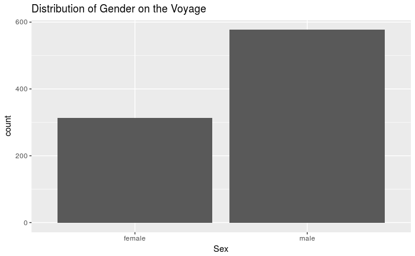

```r
ggplot(data = training) + geom_bar(aes(x = Sex)) + ggtitle("Distribution of Gender on the Voyage")
```

Age is a bit of a different story. There are 177 rows for which age is not available. We will probably need to find a way to impute values for these.

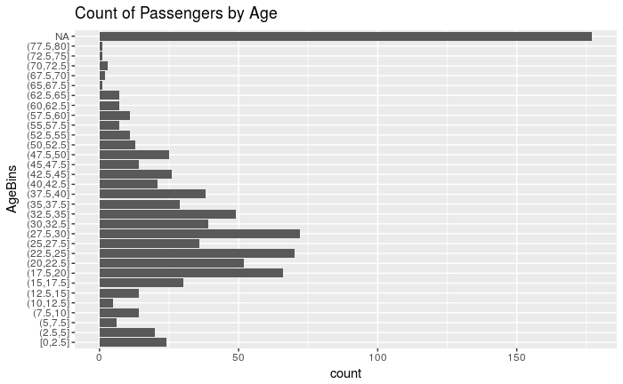

```r
ageData <- training
ageData$AgeBins <- ageData$Age %>% cut_interval(length = 2.5)
ageData %>% group_by(AgeBins) %>% ggplot() + geom_bar(aes(x = AgeBins)) + coord_flip() + ggtitle("Count of Passengers by Age")
```

The spread of ages appears to be almost normally distributed around the age of 30. Due to the reatively low counts of passengers at the younger and older ages, we should expect more variability in survival rates and be less surprised when they differ from other age groups.